# Ruggeri et al 2022 Author diversity calculation

Sakshi

2023-02-15

In this script, we compute author diversity by using author’s institution affiliation as a proxy. We first coded all 171 author names and their institution affiliation using the Global North-South classification. To measure this, we followed the United Nations’ Finance Center for South-South Cooperation (http://www.fc-ssc.org/en/partnership_program/south_south_countries), which is considered as a reliable source including a list of 78 countries (including Korea and Singapore which are highly developed country and part of the Four Asian Tigers). We also corroborated this list by following the Human Development Index (HDI) and ITU’s Telecommunication Development Bureau region classifications (https://www.itu.int/en/ITU-D/Statistics/Pages/definitions/regions.aspx) which suggests that the Global South broadly comprise Africa, Latin America and the Caribbean, and Asia (without Israel, Japan, Singapore, and the Republic of Korea).

## Load Libraries

```r
if (!require("pacman")) install.packages("pacman")             # install the package manager pacman
```

```r
# load packages with "p_load"
pacman::p_load("tidyverse", "readxl", "plyr", "ggplot2", "gtsummary", "knitr", "maps", "mapproj", "ggpubr")

knitr::opts_chunk$set(echo = TRUE)
```

## Import the data

```r
# first remove existing variables from the working space
rm(list=ls())

# load data
# setwd()
df <- read_excel('Ruggeri et al 2022_author diversity.xlsx') %>%
  dplyr::rename(Region_affiliation = "Region",
                Area_affiliation = "Area")
```

## Author Country Diversity

We calculate the number of studies based on global area, author affiliation

```r
#Region-wise distribution
prop.table(table(df$"Region_affiliation"))
```

```
##
##            Africa              Asia    Eastern Europe     Latin Ameirca
##       0.017543860       0.093567251       0.111111111       0.035087719
##              MENA     North America North-West Europe           Oceania
##       0.023391813       0.216374269       0.374269006       0.005847953
##   Southern Europe
##       0.122807018
```

```r
#Display the number of studies for each global area (Global North vs Global South)
table(df$'Author Country Affiliation')
```

```
##
##         Argentina         Australia           Austria           Belgium
##                 2                 1                 3                 3
##            Brazil          Bulgaria            Canada             China
##                 2                 3                 2                 4
##           Croatia    Czech Republic           Denmark             Egypt
##                 3                 5                 3                 1
##           Estonia            France           Georgia           Germany
##                 1                 1                 1                 9
##           Hungary         Indonesia              Iran           Ireland
##                 1                 2                 1                 1
##            Israel             Italy             Japan        Kazakhstan
##                 1                 4                 3                 2
##           Lebanon            México             Nepal       Netherlands
##                 1                 1                 2                10
##           Nigeria   North Macedonia            Norway          Paraguay
##                 2                 1                 5                 1
##            Poland          Portugal Republic of Korea           Romania
##                 2                 2                 1                 3
##            Serbia         Singapore          Slovenia      South Africa
##                 8                 2                 2                 1
##             Spain            Sweden       Switzerland                UK
##                 2                 1                 1                27
##           Ukraine               USA
##                 2                35
```

```r
prop.table(table(df$Area_affiliation))
```

```
##
## Global North Global South
##     0.871345     0.128655
```

```r
#Create a table
region <- select(df, c("Region_affiliation", "Area_affiliation", "Author Country Affiliation"))
region
```

```
## # A tibble: 171 × 3
##    Region_affiliation Area_affiliation `Author Country Affiliation`
##    <chr>              <chr>            <chr>
##  1 North America      Global North     USA
##  2 North-West Europe  Global North     Belgium
##  3 Southern Europe    Global North     Serbia
##  4 North-West Europe  Global North     Netherlands
##  5 North America      Global North     USA
##  6 North-West Europe  Global North     UK
##  7 MENA               Global South     Lebanon
##  8 Asia               Global South     Nepal
##  9 Asia               Global South     Nepal
## 10 North-West Europe  Global North     Denmark
## # ℹ 161 more rows
```

```r
#Save a descriptive table of author diversity by country
region_table <- region |> tbl_summary(
    by = Area_affiliation,
    missing = "no",
  ) %>%
  add_overall() %>% # add column with total number of non-missing observations
  modify_header(label = "**Global regions**") %>% # update the column header
  bold_labels()
region_table
```

| **Global regions** | **Overall**, N = 171<sup>1</sup> | **Global North**, N = 149<sup>1</sup> | **Global South**, N = 22<sup>1</sup> |
| --- | --- | --- | --- |
| Region_affiliation |  |  |  |
| Africa | 3 (1.8%) | 0 (0%) | 3 (14%) |
| Asia | 16 (9.4%) | 6 (4.0%) | 10 (45%) |
| Eastern Europe | 19 (11%) | 19 (13%) | 0 (0%) |
| Latin Ameirca | 6 (3.5%) | 0 (0%) | 6 (27%) |
| MENA | 4 (2.3%) | 1 (0.7%) | 3 (14%) |
| North America | 37 (22%) | 37 (25%) | 0 (0%) |
| North-West Europe | 64 (37%) | 64 (43%) | 0 (0%) |
| Oceania | 1 (0.6%) | 1 (0.7%) | 0 (0%) |
| Southern Europe | 21 (12%) | 21 (14%) | 0 (0%) |
| Author Country Affiliation |  |  |  |
| Argentina | 2 (1.2%) | 0 (0%) | 2 (9.1%) |
| Australia | 1 (0.6%) | 1 (0.7%) | 0 (0%) |
| Austria | 3 (1.8%) | 3 (2.0%) | 0 (0%) |
| Belgium | 3 (1.8%) | 3 (2.0%) | 0 (0%) |
| Brazil | 2 (1.2%) | 0 (0%) | 2 (9.1%) |
| Bulgaria | 3 (1.8%) | 3 (2.0%) | 0 (0%) |
| Canada | 2 (1.2%) | 2 (1.3%) | 0 (0%) |
| China | 4 (2.3%) | 0 (0%) | 4 (18%) |
| Croatia | 3 (1.8%) | 3 (2.0%) | 0 (0%) |
| Czech Republic | 5 (2.9%) | 5 (3.4%) | 0 (0%) |
| Denmark | 3 (1.8%) | 3 (2.0%) | 0 (0%) |
| Egypt | 1 (0.6%) | 0 (0%) | 1 (4.5%) |
| Estonia | 1 (0.6%) | 1 (0.7%) | 0 (0%) |
| France | 1 (0.6%) | 1 (0.7%) | 0 (0%) |
| Georgia | 1 (0.6%) | 1 (0.7%) | 0 (0%) |
| Germany | 9 (5.3%) | 9 (6.0%) | 0 (0%) |
| Hungary | 1 (0.6%) | 1 (0.7%) | 0 (0%) |
| Indonesia | 2 (1.2%) | 0 (0%) | 2 (9.1%) |
| Iran | 1 (0.6%) | 0 (0%) | 1 (4.5%) |
| Ireland | 1 (0.6%) | 1 (0.7%) | 0 (0%) |
| Israel | 1 (0.6%) | 1 (0.7%) | 0 (0%) |
| Italy | 4 (2.3%) | 4 (2.7%) | 0 (0%) |
| Japan | 3 (1.8%) | 3 (2.0%) | 0 (0%) |
| Kazakhstan | 2 (1.2%) | 0 (0%) | 2 (9.1%) |
| Lebanon | 1 (0.6%) | 0 (0%) | 1 (4.5%) |
| México | 1 (0.6%) | 0 (0%) | 1 (4.5%) |
| Nepal | 2 (1.2%) | 0 (0%) | 2 (9.1%) |
| Netherlands | 10 (5.8%) | 10 (6.7%) | 0 (0%) |
| Nigeria | 2 (1.2%) | 0 (0%) | 2 (9.1%) |
| North Macedonia | 1 (0.6%) | 1 (0.7%) | 0 (0%) |
| Norway | 5 (2.9%) | 5 (3.4%) | 0 (0%) |
| Paraguay | 1 (0.6%) | 0 (0%) | 1 (4.5%) |
| Poland | 2 (1.2%) | 2 (1.3%) | 0 (0%) |
| Portugal | 2 (1.2%) | 2 (1.3%) | 0 (0%) |
| Republic of Korea | 1 (0.6%) | 1 (0.7%) | 0 (0%) |
| Romania | 3 (1.8%) | 3 (2.0%) | 0 (0%) |
| Serbia | 8 (4.7%) | 8 (5.4%) | 0 (0%) |
| Singapore | 2 (1.2%) | 2 (1.3%) | 0 (0%) |
| Slovenia | 2 (1.2%) | 2 (1.3%) | 0 (0%) |
| South Africa | 1 (0.6%) | 0 (0%) | 1 (4.5%) |
| Spain | 2 (1.2%) | 2 (1.3%) | 0 (0%) |
| Sweden | 1 (0.6%) | 1 (0.7%) | 0 (0%) |
| Switzerland | 1 (0.6%) | 1 (0.7%) | 0 (0%) |
| UK | 27 (16%) | 27 (18%) | 0 (0%) |
| Ukraine | 2 (1.2%) | 2 (1.3%) | 0 (0%) |
| USA | 35 (20%) | 35 (23%) | 0 (0%) |

<sup>1</sup> n (%)

```r
#save the region-wise table
#region_table  %>% as_flex_table() %>%
  #flextable::save_as_docx(path = "//author.docx")
```

## Author Country visualisations

First, we plot only Global South countries

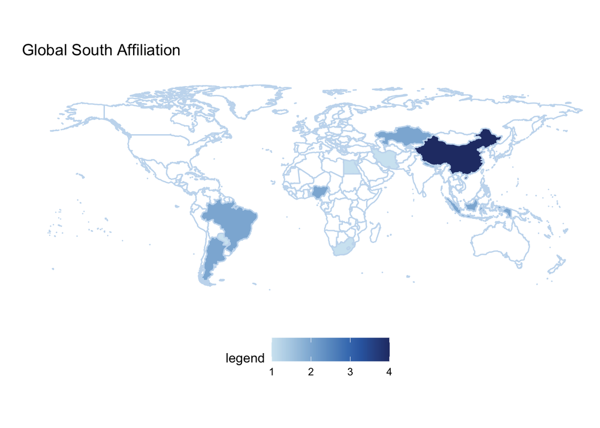

```r
#Load World map data
WorldData <- map_data('world') %>% filter(region != "Antarctica") %>% fortify

#Select Global South author data
df <- data.frame(region=c('Lebanon','Nepal','Brazil', "México", "Kazakhstan", "China", "Nigeria", "Egypt", "Indonesia", "Argentina", "Iran", "South Africa", "Paraguay"),
                 value=c(1, 2, 2, 1, 2, 4, 2, 1, 2, 2, 1, 1, 1),
                 stringsAsFactors=FALSE)


#Plot Global South author country data
plot1 <- ggplot() +
    geom_map(data = WorldData, map = WorldData,
                  aes(x = long, y = lat, group = group, map_id=region),
                  fill = "white", colour = "#C6DBEF", size=0.5) +
    geom_map(data = df, map=WorldData,
                  aes(fill=value, map_id=region),
                  colour="#C6DBEF", size=0.5) +
    coord_map("rectangular", lat0=0, xlim=c(-180,180), ylim=c(-60, 90)) +
    colorspace::scale_fill_continuous_sequential(palette = "Blues",
                                               begin = .18, end = .99) +
    scale_y_continuous(breaks=c()) +
    scale_x_continuous(breaks=c()) +
    labs(fill="legend", title="Global South Affiliation", x="", y="") +
  theme_classic() +
theme(legend.position = "bottom",
        legend.key.size = unit(0.7, 'cm'),
        strip.background = element_blank(), panel.spacing = unit(4, "mm"), panel.background = element_blank())
plot1
```

```r
# save the plot
# ggsave("fig2.pdf", plot1, device = "pdf", width=18, height = 15)
```

*All author country affiliation plot* #Authors were affiliated to the following countries based in the Global South - #The following countries were represented: ‘Lebanon’,‘Nepal’,‘Brazil’, “México”, “Kazakhstan”, “China”, “Nigeria”, “Egypt”, “Indonesia”, “Argentina”, “Iran”, “South Africa”, “Paraguay” #11 were not represented: “Jordon”, “India”, “Turkey”, “Pakistan”, “Panama”, “Vietnam”, “Malaysia”, “Kenya”, “Ghana”, “Ethiopia”, Uruguay

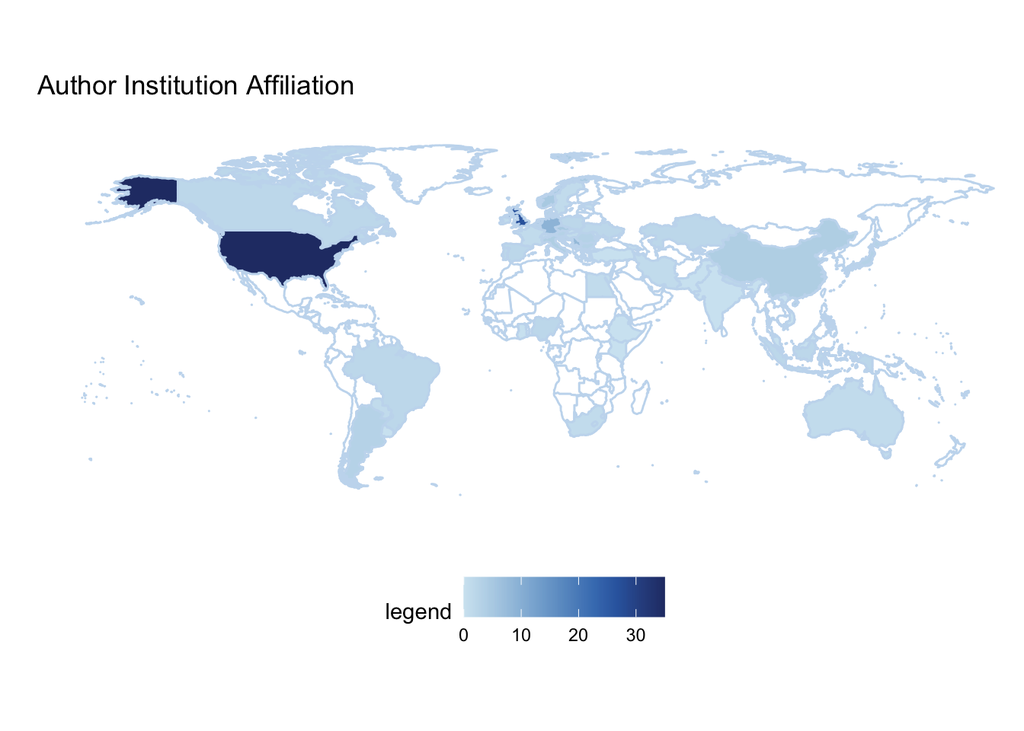

```r
#Select all author country data
df3 <- data.frame(region=c('Lebanon','Nepal','Brazil', "México", "Kazakhstan", "China", "Singapore", "Nigeria", "Egypt", "Indonesia", "Argentina", "Iran", "South Africa", "Paraguay", "USA", "UK", "Australia", "Austria", "Belgium", "Bulgaria", "Canada", "Croatia", "Czech Republic", "Denmark", "Estonia", "France", "Georgia", "Germany", "Hungary", "Ireland", "Italy", "Israel", "Japan", "Netherlands", "North Macedonia", "Norway", "Poland", "Portugal", "Republic of Korea", "Serbia", "Romania", "Slovenia","Spain","Sweden", "Ukraine", "Switzerland", "Bosnia_and_Herzegovina", "Moldova", "Montenegro", "Slovakia", "Jordon", "India", "Turkey", "Pakistan", "Panama", "Vietnam", "Malaysia", "Kenya", "Uruguay", "Ghana", "Ethiopia"),
                 value=c(1,2,2,1, 2, 4, 2, 2, 1, 2, 3, 1, 1, 1, 35, 27, 1, 3, 3, 3, 2, 3, 5, 3, 1, 1, 1, 9, 1, 1, 4, 1, 3, 10, 1, 5, 2, 2, 1, 8, 3, 2, 2, 1, 2, 1, 0, 0, 0, 0, 0, 0, 0, 0, 0, 0, 0, 0, 0, 0, 0),
                 stringsAsFactors=FALSE)


#Plot all author country data
plot2 <- ggplot() +
    geom_map(data = WorldData, map = WorldData,
                  aes(x = long, y = lat, group = group, map_id=region),
                  fill = "white", colour = "#C6DBEF", size=0.5) +
    geom_map(data = df3, map=WorldData,
                  aes(fill=value, map_id=region),
                  colour="#C6DBEF", size=0.5) +
    coord_map("rectangular", lat0=0, xlim=c(-180,180), ylim=c(-60, 90)) +
    colorspace::scale_fill_continuous_sequential(palette = "Blues",
                                               begin = .18, end = .99) +
    scale_y_continuous(breaks=c()) +
    scale_x_continuous(breaks=c()) +
    labs(fill="legend", title="Author Institution Affiliation", x="", y="") +
  theme_classic() +
theme(legend.position = "bottom",
        legend.key.size = unit(0.7, 'cm'),
        strip.background = element_blank(), panel.spacing = unit(4, "mm"), panel.background = element_blank())
plot2
```

```r
ggsave("fig2.pdf", plot2, device = "pdf", width=18, height = 15)
```